# Personal Movement

Richie Liew

Nov 13, 2016

Library require for this report.

```r
library(lattice)
```

#### Introduction

It is now possible to collect a large amount of data about personal movement using activity monitoring devices such as a *Fitbit*, *Nike Fuelband*, or *Jawbone Up*. These type of devices are part of the “quantified self” movement – a group of enthusiasts who take measurements about themselves regularly to improve their health, to find patterns in their behavior, or because they are tech geeks. But these data remain under-utilized both because the raw data are hard to obtain and there is a lack of statistical methods and software for processing and interpreting the data.

This assignment makes use of data from a personal activity monitoring device. This device collects data at 5 minute intervals through out the day. The data consists of two months of data from an anonymous individual collected during the months of October and November, 2012 and include the number of steps taken in 5 minute intervals each day.

The data for this assignment can be downloaded from the course web site:

- Dataset: Activity monitoring data [52K] The variables included in this dataset are:
- **steps**: Number of steps taking in a 5-minute interval (missing values are coded as 𝙽𝙰)
- **date**: The date on which the measurement was taken in YYYY-MM-DD format
- **interval**: Identifier for the 5-minute interval in which measurement was taken

The dataset is stored in a comma-separated-value (CSV) file and there are a total of 17,568 observations in this dataset.

#### Loading and preprocessing the data

Show any code that is needed to

1. Load the data (i.e. read.csv())

```r
act <- read.csv("./data/activity.csv", stringsAsFactors = FALSE)
```

2. Process/transform the data (if necessary) into a format suitable for your analysis

```r
act$date <- as.POSIXct(act$date, format="%Y-%m-%d")
act <- data.frame(date=act$date,
                           weekday=tolower(weekdays(act$date)),
                           steps=act$steps,
                           interval=act$interval)
act <- cbind(act, daytype=ifelse(act$weekday == "saturday" |
                                     act$weekday == "sunday", "weekend",
                                     "weekday"))
act <- data.frame(date=act$date,
                       weekday=act$weekday,
                       daytype=act$daytype,
                       interval=act$interval,
                       steps=act$steps)
```

Display the first few rows of the activity data frame as shown below:

```r
head(act)
```

```
##         date weekday daytype interval steps
## 1 2012-10-01  monday weekday        0    NA
## 2 2012-10-01  monday weekday        5    NA
## 3 2012-10-01  monday weekday       10    NA
## 4 2012-10-01  monday weekday       15    NA
## 5 2012-10-01  monday weekday       20    NA
## 6 2012-10-01  monday weekday       25    NA
```

#### What is mean total number of steps taken per day?

For this part of the assignment, you can ignore the missing values in the dataset.

1. Calculate the total number of steps taken per day

```r
sum_steps <- aggregate(act$steps, by=list(act$date), FUN=sum, na.rm=TRUE)
names(sum_steps) <- c("date", "total")
```

2. If you do not understand the difference between a histogram and a barplot, research the difference between them. Make a histogram of the total number of steps taken each day

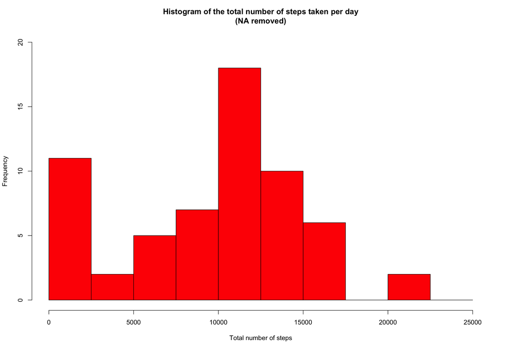

```r
hist(sum_steps$total,
     breaks=seq(from=0, to=25000, by=2500),
     col="red",
     xlab="Total number of steps",
     ylim=c(0, 20),
     main="Histogram of the total number of steps taken per day\n(NA removed)")
```

3. Calculate and report the mean and median of the total number of steps taken per day

```r
mean(sum_steps$total)
```

```
## [1] 9354.23
```

```r
median(sum_steps$total)
```

```
## [1] 10395
```

##### What is the average daily activity pattern?

1. Make a time series plot (i.e. 𝚝𝚢𝚙𝚎 = “𝚕”) of the 5-minute interval (x-axis) and the average number of steps taken, averaged across all days (y-axis)

```r
mean_steps <- aggregate(act$steps, by=list(act$interval), FUN=mean, na.rm=TRUE)
names(mean_steps) <- c("interval", "mean")
```

Let’s display the mean_steps data frame.

```r
head(mean_steps)
```

```
##   interval      mean
## 1        0 1.7169811
## 2        5 0.3396226
## 3       10 0.1320755
## 4       15 0.1509434
## 5       20 0.0754717
## 6       25 2.0943396
```

The following shows a time series plot of the average number of steps per interval.

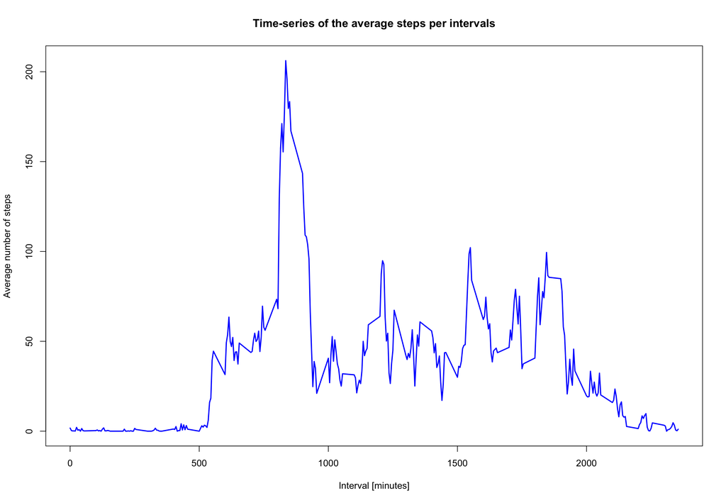

```r
plot(mean_steps$interval,
     mean_steps$mean,
     type="l",
     col="blue",
     lwd=2,
     xlab="Interval [minutes]",
     ylab="Average number of steps",
     main="Time-series of the average steps per intervals")
```

2. Which 5-minute interval, on average across all the days in the dataset, contains the maximum number of steps?

```r
max_steps <- which(mean_steps$mean == max(mean_steps$mean))
max_steps_interval <- mean_steps[max_steps, 1]
```

The 5-minute interval that contains the maximum number of steps is 835 all day.

```r
max_steps_interval
```

```
## [1] 835
```

#### Imputing missing values

Note that there are a number of days/intervals where there are missing values (coded as 𝙽𝙰). The presence of missing days may introduce bias into some calculations or summaries of the data.

1. Calculate and report the total number of missing values in the dataset (i.e. the total number of rows with 𝙽𝙰s)

```r
count_NA <- sum(is.na(act$steps))
```

The total number of NA’s is 2304

```r
count_NA
```

```
## [1] 2304
```

2. Devise a strategy for filling in all of the missing values in the dataset. The strategy does not need to be sophisticated. For example, you could use the mean/median for that day, or the mean for that 5-minute interval, etc.

```r
pos_with_na <- which(is.na(act$steps))
mean_vector <- rep(mean(act$steps, na.rm=TRUE), times=length(pos_with_na))
head(mean_vector)
```

```
## [1] 37.3826 37.3826 37.3826 37.3826 37.3826 37.3826
```

3. Create a new dataset that is equal to the original dataset but with the missing data filled in.

```r
act[pos_with_na, "steps"] <- mean_vector
head(act)
```

```
##         date weekday daytype interval   steps
## 1 2012-10-01  monday weekday        0 37.3826
## 2 2012-10-01  monday weekday        5 37.3826
## 3 2012-10-01  monday weekday       10 37.3826
## 4 2012-10-01  monday weekday       15 37.3826
## 5 2012-10-01  monday weekday       20 37.3826
## 6 2012-10-01  monday weekday       25 37.3826
```

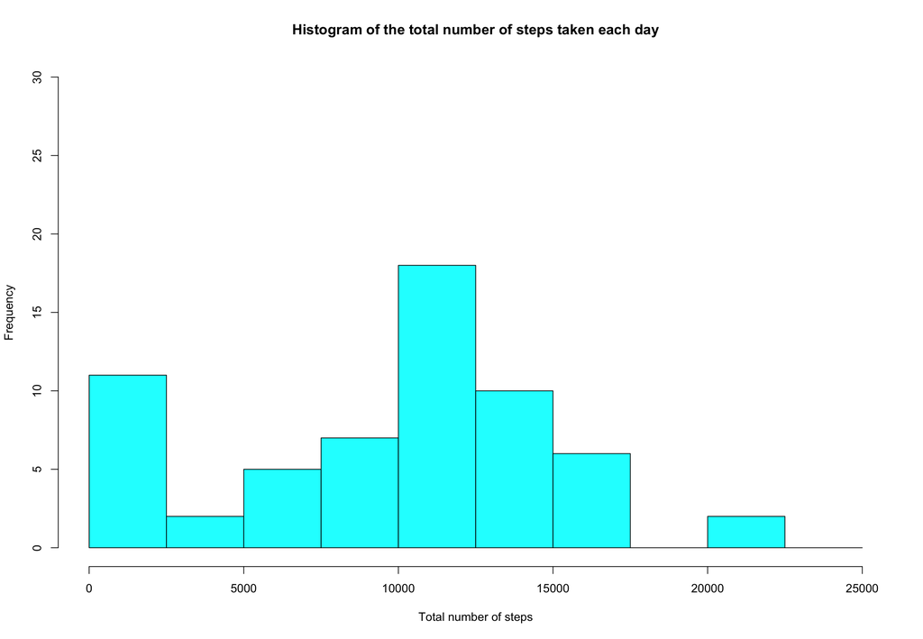

```r
hist(sum_steps$total,
     breaks=seq(from=0, to=25000, by=2500),
     col="cyan",
     xlab="Total number of steps",
     ylim=c(0, 30),
     main="Histogram of the total number of steps taken each day")
```

Mean and Median of the data frame:

```r
mean(sum_steps$total)
```

```
## [1] 9354.23
```

```r
median(sum_steps$total)
```

```
## [1] 10395
```

#### Are there differences in activity patterns between weekdays and weekends?

For this part the 𝚠𝚎𝚎𝚔𝚍𝚊𝚢𝚜() function may be of some help here. Use the dataset with the filled-in missing values for this part.

1. Create a new factor variable in the dataset with two levels – “weekday” and “weekend” indicating whether a given date is a weekday or weekend day.

```r
head(act)
```

```
##         date weekday daytype interval   steps
## 1 2012-10-01  monday weekday        0 37.3826
## 2 2012-10-01  monday weekday        5 37.3826
## 3 2012-10-01  monday weekday       10 37.3826
## 4 2012-10-01  monday weekday       15 37.3826
## 5 2012-10-01  monday weekday       20 37.3826
## 6 2012-10-01  monday weekday       25 37.3826
```

2. Make a panel plot containing a time series plot (i.e. 𝚝𝚢𝚙𝚎 = “𝚕”) of the 5-minute interval (x-axis) and the average number of steps taken, averaged across all weekday days or weekend days (y-axis). See the README file in the GitHub repository to see an example of what this plot should look like using simulated data.

```r
mean_steps <- aggregate(act$steps, by=list(act$daytype, act$weekday, act$interval), mean)
names(mean_steps) <- c("daytype", "weekday", "interval", "mean")
head(mean_steps)
```

```
##   daytype  weekday interval     mean
## 1 weekday   friday        0 8.307244
## 2 weekday   monday        0 9.418355
## 3 weekend saturday        0 4.672825
## 4 weekend   sunday        0 4.672825
## 5 weekday thursday        0 9.375844
## 6 weekday  tuesday        0 0.000000
```

Time series plot which show the interval of the number of steps taken weekday & weekend.

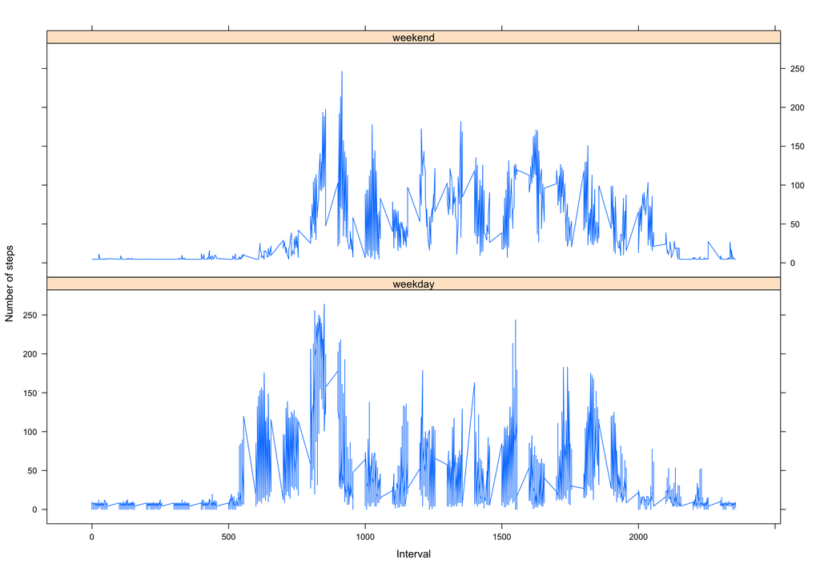

```r
xyplot(mean ~ interval | daytype, mean_steps,
       type="l",
       lwd=1,
       xlab="Interval",
       ylab="Number of steps",
       layout=c(1,2))
```